# Portfolio Assignment 2 Part 2, Study Group 5, Methods 3, 2021, autumn semester

Mina Almasi (MA, 202005465)

Daniel Blumenkranz (DB, 202008989)

Anton Drasbæk Schiønning (ADS, 202008161)

Matilde Just Sterup (MS, 202004691)

First edit: 27/10/21, Final edit: 13/12/21

# Assignment 2; Part 2 – evaluating and comparing the models: Mixed effects modelling of response times, response counts, and accuracy

# Exercises and objectives

The objectives of the exercises of this assignment are based on: https://doi.org/10.1016/j.concog.2019.03.007

4. Download and organise the data from experiment 1
5. Use log-likelihood ratio tests to evaluate logistic regression models
6. Test linear hypotheses
7. Estimate psychometric functions for the Perceptual Awareness Scale and evaluate them

# EXERCISE 4 - Download and organise the data from experiment 1

Go to https://osf.io/ecxsj/files/ and download the files associated with Experiment 1 (there should be 29).  
The data is associated with Experiment 1 of the article at the following DOI https://doi.org/10.1016/j.concog.2019.03.007

### (GROUP) 1) Put the data from all subjects into a single data frame - note that some of the subjects do not have the *seed* variable. For these subjects, add this variable and make in *NA* for all observations. (The *seed* variable will not be part of the analysis and is not an experimental variable)

```r
data <- read_bulk(directory = "/Users/antondrasbaek/Desktop/Uni/3rd Semester/Methods 3/github_methods_3/week_05/experiment_1")
```

Investigating the seed variable:

```r
is_empty(data$seed) #checking whether the seed column is empty or NULL (returns TRUE if empty, FALSE if not)
```

```
## [1] FALSE
```

```r
unique(data$seed) #looking at the unique values in the seed column
```

```
##  [1] 93764 33409 25494 63023 21722 91366    NA 28587  3849 90992 66788 16969
## [13] 30991 73521  3688 98435 25444  3733 80613 14592  4688 66410 14408 90174
## [25] 24431 41191 18320 61503  4691 23300
```

Using the is_empty() function, we observe that no values in the seed column are empty. The NA’s are already inserted as seen by applying the unique() function to check for unique values. The insertion of NA’s may have something to do with the read_bulk() function and how it reads in the data.

$~$

#### (ADS) i. Factorise the variables that need factorising

```r
data$trial.type <- as.factor(data$trial.type)
data$pas <- as.factor(data$pas)
data$trial <- as.factor(data$trial) #since it is not exactly continuous, and we do not expect a linear relationship
data$cue <- as.factor(data$cue)
data$task <- as.factor(data$task)
data$target.type <- as.factor(data$target.type)
data$obj.resp <- as.factor(data$obj.resp)
data$subject <- as.factor(data$subject)

ls.str(data)
```

```
## cue :  Factor w/ 36 levels "0","1","2","3",..: 1 1 1 1 1 1 1 1 1 1 ...
## even.digit :  int [1:25602] 8 4 2 8 6 6 6 4 4 8 ...
## File :  chr [1:25602] "001.csv" "001.csv" "001.csv" "001.csv" "001.csv" "001.csv" ...
## jitter.x :  num [1:25602] -0.431 -0.292 0.308 0.238 -0.427 ...
## jitter.y :  num [1:25602] -0.335 -0.182 0.406 0.175 -0.221 ...
## obj.resp :  Factor w/ 2 levels "e","o": 1 2 1 2 1 2 2 1 1 2 ...
## odd.digit :  int [1:25602] 9 5 5 9 3 9 3 5 7 9 ...
## pas :  Factor w/ 4 levels "1","2","3","4": 4 4 3 2 3 2 1 1 1 4 ...
## rt.obj :  num [1:25602] 1.418 0.86 0.746 1.676 0.847 ...
## rt.subj :  num [1:25602] 4.93 8.67 8.41 2.13 1.82 ...
## seed :  int [1:25602] 93764 93764 93764 93764 93764 93764 93764 93764 93764 93764 ...
## subject :  Factor w/ 29 levels "1","2","3","4",..: 1 1 1 1 1 1 1 1 1 1 ...
## target.contrast :  num [1:25602] 0.1 0.1 0.1 0.1 0.1 0.1 0.1 0.1 0.1 0.1 ...
## target.frames :  int [1:25602] 9 8 7 6 5 4 3 2 1 9 ...
## target.type :  Factor w/ 2 levels "even","odd": 1 2 1 2 1 2 1 2 1 2 ...
## task :  Factor w/ 3 levels "pairs","quadruplet",..: 2 2 2 2 2 2 2 2 2 2 ...
## trial :  Factor w/ 864 levels "0","1","2","3",..: 1 2 3 4 5 6 7 8 9 10 ...
## trial.type :  Factor w/ 2 levels "experiment","practice": 2 2 2 2 2 2 2 2 2 2 ...
```

The factorisation of variables have been made on the basis of Assignment 2 Part 1 where arguments were presented for the correct class of each variable.

$~$

#### (MS) ii. Remove the practice trials from the dataset (see the *trial.type* variable)

```r
data <- data %>% filter(trial.type!= "practice")

unique(data$trial.type) #checking whether "practice" has been filtered out
```

```
## [1] experiment
## Levels: experiment practice
```

$~$

#### (MA) iii. Create a *correct* variable

```r
data$correct <- ifelse(data$obj.resp == "e" & data$target.type == "even"|data$obj.resp == "o" & data$target.type == "odd", 1, 0)

data$correct <- as.factor(data$correct)
```

The *correct* variable was also converted to a factor as it is binary data coded as 0 for *incorrect* and 1 for a *correct* answer.

$~$

##### (ADS) iv. Describe how the *target.contrast* and *target.frames* variables differ compared to the data from part 1 of this assignment

In this assignment (*Assignment 2; Part 2*), we are working with **experiment 1** whereas we worked with experiment 2 in *Assignment 2; Part 1*. A few differences should be noted when working with the following variables:

$~$

*target.contrast* is the contrast between the target and the background. In experiment 1, it is held **constant** across participants whereas each participant had their own *target.contrast* in experiment 2.

$~$

*target.frames* is the amount of frames in which the target is shown (11.8 ms pr frame). In experiment 2, it was held constant at 3 frames. On the other hand, the amount of frames **varies** from 1 to 6 in the current dataset from experiment 1. *target.frames* can be considered a type of time variable as it describes the duration the target was shown. It is thus a ratio variable as the ratio of two measurements has a meaningful interpretation. That is, 4 *target.frames* (47.2 ms) is twice as long as 2 *target.frames* (23.6 ms). For this reason, its class is coded as an integer:

```r
class(data$target.frames)
```

```
## [1] "integer"
```

$~$

# EXERCISE 5 - Use log-likelihood ratio tests to evaluate logistic regression models

### (MA) 1) Do logistic regression - *correct* as the dependent variable and *target.frames* as the independent variable. (Make sure that you understand what *target.frames* encode). Create two models - a pooled model and a partial-pooling model. The partial-pooling model should include a subject-specific intercept.

```r
## Complete pooling model ##
cp <- glm(correct~target.frames, data = data, family = binomial(link = logit))

## Partial pooling model ##
pp <- glmer(correct~target.frames + (1|subject), data = data, family = binomial(link = logit))
```

#### (ADS) i. the likelihood-function for logistic regression is: $L(p)={\displaystyle\prod_{i=1}^Np^{y_i}(1-p)^{(1-y_i)}}$ (Remember the probability mass function for the Bernoulli Distribution). Create a function that calculates the likelihood.

```r
likelihood_function <- function(model, y_i){
  p <- fitted.values(model)
  y_i <- as.numeric(as.character(y_i)) #hack to go back to 0's and 1's

  likelihood <- prod((p^y_i)*((1-p)^(1-y_i)))
  return(likelihood)
}
```

#### (MS) ii. the log-likelihood-function for logistic regression is: $l(p) = {\displaystyle\sum_{i=1}^N}[y_i\ln{p}+(1-y_i)\ln{(1-p)}$. Create a function that calculates the log-likelihood

```r
log_likelihood_function <- function(model, y_i){
  p <- fitted.values(model)
  y_i <- as.numeric(as.character(y_i))

  log_likelihood <- sum(y_i*log(p)+(1-y_i)*log(1-p))
  return(log_likelihood)
}
```

#### (DB) iii. apply both functions to the pooling model you just created. Make sure that the log-likelihood matches what is returned from the *logLik* function for the pooled model. Does the likelihood-function return a value that is surprising? Why is the log-likelihood preferable when working with computers with limited precision?

```r
## APPLYING the functions ##
likelihood_function(cp, data$correct)
```

```
## [1] 0
```

```r
log_likelihood_function(cp, data$correct)
```

```
## [1] -10865.25
```

```r
logLik(cp)
```

```
## 'log Lik.' -10865.25 (df=2)
```

Our *log_likelihood_function* gives the same result as the *logLik* function (-10865.25). To obtain the exact y-values in the exact same order is extremely unlikely for any model given the large size of our dataset. Thus, the likelihood will always be low in this case.

The likelihood is so close to zero that our computer (which has limited precision) displays *0* as output of the *likelihood_function*. This is why we calculate the log-likelihood as it results in a number further from zero. That is, the log-likelihood function does not require as much computer precision to display its output.

$~$

#### (MA) iv. now show that the log-likelihood is a little off when applied to the partial pooling model - (the likelihood function is different for the multilevel function - see section 2.1 of https://www.researchgate.net/profile/Douglas-Bates/publication/2753537_Computational_Methods_for_Multilevel_Modelling/links/00b4953b4108d73427000000/Computational-Methods-for-Multilevel-Modelling.pdf if you are interested)

```r
log_likelihood_function(pp, data$correct)
```

```
## [1] -10565.53
```

```r
logLik(pp)
```

```
## 'log Lik.' -10622.03 (df=3)
```

Our *log_likelihood_function* (-10565.53) does not exactly match the *logLik* function (-10622.03) when applied to a partial pooling model (*pp*). This is expected considering that the likelihood is calculated differently for multilevel models which is not taken into account in the formula used in our function.

$~$

### (ADS, MS) 2) Use log-likelihood ratio tests to argue for the addition of predictor variables, start from the null model, `glm(correct ~ 1, 'binomial', data)`, then add subject-level intercepts, then add a group-level effect of *target.frames* and finally add subject-level slopes for *target.frames*. Also assess whether or not a correlation between the subject-level slopes and the subject-level intercepts should be included.

(ADS):

```r
## null model ##
m0 <- glm(correct ~ 1, family = binomial(link = logit), data=data)

## subject level intercepts ##
m1 <- glmer(correct ~ 1 + (1|subject), family = binomial(link = logit), data=data)

## added group level effect of target.frames ##
m2 <- glmer(correct ~ 1 + target.frames + (1|subject), family = binomial(link = logit), data=data)
```

(MS):

```r
## without correlation between the subject-level slopes and the subject-level intercepts ##
m3 <- glmer(correct ~ 1 + target.frames + (1+target.frames||subject), family = binomial(link = logit), data=data)

## with correlation between the subject-level slopes and the subject-level intercepts ##
m4 <- glmer(correct ~ 1 + target.frames + (1+target.frames|subject), family = binomial(link = logit), data=data)
```

(MS):

```r
## MODEL comparison ##
anova(m1, m2, m3, m4)
```

|  | npar | AIC | BIC | logLik | deviance | Chisq | Df | Pr(>Chisq) |
| --- | --- | --- | --- | --- | --- | --- | --- | --- |
| m1 | 2 | 26319.10 | 26335.35 | -13157.55 | 26315.10 | NA | NA | NA |
| m2 | 3 | 21250.06 | 21274.45 | -10622.03 | 21244.06 | 5071.03518 | 1 | 0.000000e+00 |
| m3 | 4 | 20928.58 | 20961.09 | -10460.29 | 20920.58 | 323.48672 | 1 | 2.520170e-72 |
| m4 | 5 | 20907.65 | 20948.29 | -10448.83 | 20897.65 | 22.92598 | 1 | 1.683609e-06 |

It seems that each model gradually performs significantly better than the previous model. The model where there is a correlation between the subject-level slopes and the subject-level intercepts (m4) performs significantly better in the anova() comparison on all parameters (p<.001) than the rest. Thus, a correlation should be included.

$~$

#### (GROUP) i. write a short methods section and a results section where you indicate which model you chose and the statistics relevant for that choice. Include a plot of the estimated group-level function with `xlim=c(0, 8)` that includes the estimated subject-specific functions.

$~$

**REPORT: METHODS SECTION**

The following methods section was written based on the article “*Visual expectations change subjective experience without changing performance*” (Andersen et al., 2019).

$~$

**Participants**: Experiment 1 was conducted on 29 participants of whom 18 were female and 11 were male. All participants had normal or corrected to normal vision and provided informed consent to participate. This sample size was chosen since it is twice as large as the sample sizes of two previous studies central to this experiment.

$~$

$~$

**ANALYSIS**: To predict the participants’ accuracy *correct*, we made 4 different generalised linear mixed effects models (GLMM) and calculated the log likelihood using the anova() function (see chunk 5.2 for the code). Here follows a description of each model:

m1: This model has subject level intercepts: $\text{correct} \sim 1 + (1|\text{subject})$

m2: This model is equal to m1, but also included a group level effect of target.frames: $\text{correct} \sim 1 + \text{target.frames} + (1|\text{subject})$

m3: This model is equal to m2, but also included subject-level slopes for target.frames without a correlation with the subject-level intercepts: $\text{correct} \sim 1 + \text{target.frames} + (1+\text{target.frames}||\text{subject})$

m4: This model is equal to m3, but also included a correlation between the subject-level slopes and the subject-level intercepts: $\text{correct} \sim 1 + \text{target.frames} + (1+\text{target.frames}|\text{subject})$

$~$

**RESULTS SECTION**

$~$

```r
tibble("Model" = c("m1", "m2", "m3", "m4"), "Log-likelihood" = c(logLik(m1), logLik(m2), logLik(m3), logLik(m4)))
```

| Model | Log-likelihood |
| --- | --- |
| m1 | -13157.55 |
| m2 | -10622.03 |
| m3 | -10460.29 |
| m4 | -10448.83 |

```r
round(m4@beta, 2)
```

```
## [1] -1.09  0.83
```

The plot below shows the estimated group-level function (red line) with *target.frames* on the x-axis and also includes the estimated subject-specific functions (blue lines). The dots are the responses made by each participant (correct or incorrect for 1-6 frames of target exposure.) There are multiple dots on top of each other, however each dot is see-through - the darker the color, the more dots.

$~$

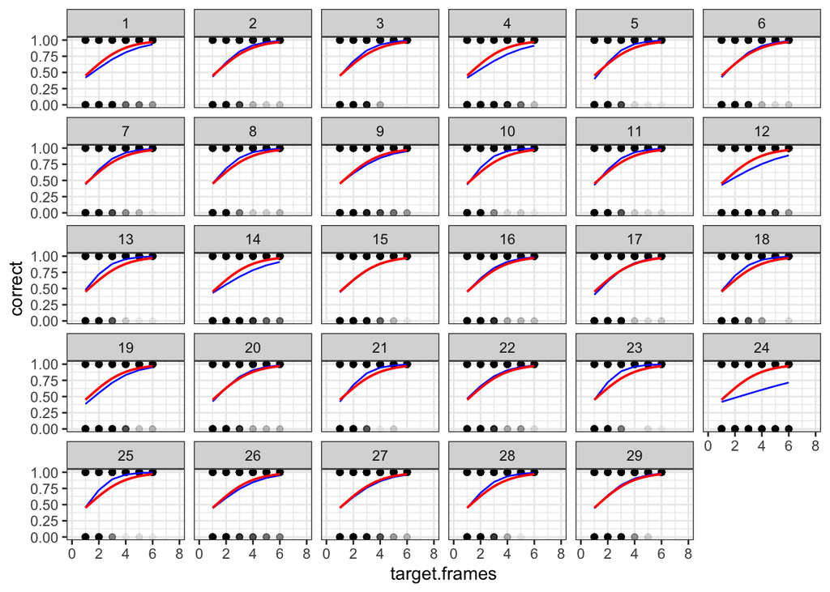

```r
fitted_values <- fitted(m4) # extract fitted values for geom_line
data2 <- data %>%
  dplyr::select(-subject) # create data without subject to override facet_wrap in plot

data2$fitted_values <- fitted_values

ggplot(data, aes(x = target.frames, y = as.numeric(as.character(correct))))+
  geom_point(aes(y=as.numeric(as.character(correct))), color = "black", alpha = 0.05)+ # add alpha to be able to better access how many dots are clumped together
  geom_line(aes(target.frames, fitted_values), color = "blue") +
  #geom_line(data = data2, aes(target.frames, fitted_values), color = "red") +
  geom_smooth(data = data2, method = "glm", se = FALSE, method.args = list(family = "binomial"), color = "red", size = 0.7) +
  facet_wrap(.~subject)+
  xlim(min = 0, max = 8)+
  labs(y = "correct") +
  theme_bw()
```

$~$

#### (ADS) ii. also include in the results section whether the fit didn’t look good for any of the subjects. If so, identify those subjects in the report, and judge (no statistical test) whether their performance (accuracy) differed from that of the other subjects. Was their performance better than chance? (Use a statistical test this time) (50 %)

```r
subject24 <- data %>%
  filter(subject == 24)

t.test(x = as.numeric(as.character(subject24$correct)), mu = 0.5)
```

```
##
##  One Sample t-test
##
## data:  as.numeric(as.character(subject24$correct))
## t = 4.026, df = 873, p-value = 6.167e-05
## alternative hypothesis: true mean is not equal to 0.5
## 95 percent confidence interval:
##  0.5345964 0.6004150
## sample estimates:
## mean of x
## 0.5675057
```

**CONTINUATION OF REPORT 5.2i**: The fit suits most of the subjects well. However, the function for subject 24 deviates a lot from the group-specific function. When inspecting the accuracies, it also appears that subject 24 differed from the other subjects. From the plot, we can tell that subject 24 has many incorrect trials even with 6 target frames (indicated by the fully black dot at accuracy = 0, target.frames = 6) which is not the case for a lot of the participants. Subject 24 has a mean accuracy of 0.5675. To assess whether this performance was better than pure chance, we ran a one-sample t-test against a theoretical value of 0.5. The t-test showed that subject 24 did differ significantly from pure chance (50%), $t(873) = 4.026, p < .001$.

$~$

### (DB) 3) Now add *pas* to the group-level effects - if a log-likelihood ratio test justifies this, also add the interaction between *pas* and *target.frames* and check whether a log-likelihood ratio test justifies this

```r
m5 <- glmer(correct ~ 1 + target.frames + pas + (1+target.frames|subject), family = binomial(link = logit), data=data)
m6 <- glmer(correct ~ 1 + target.frames * pas + (1+target.frames|subject), family = binomial(link = logit), data=data)

logLiks <- tibble("Model" = c("m4 (without pas)", "m5 (with pas)", "m6 (with pas & interaction)"), "Log-likelihood" = c(logLik(m4), logLik(m5), logLik(m6)))

logLiks
```

| Model | Log-likelihood |
| --- | --- |
| m4 (without pas) | -10448.825 |
| m5 (with pas) | -9931.828 |
| m6 (with pas & interaction) | -9742.039 |

Adding *pas* to the group-level effects increases the log-likelihood (i.e., models m5 and m6 compared to m4 without *pas* as a group-level effect) and it is thus justified. The same is the case for the interaction between *pas* and *target.frames* and we therefore also keep that as part of the model.

$~$

#### (DB) i. if your model doesn’t converge, try a different optimizer

Our model converged.

#### (DB) ii. plot the estimated group-level functions over `xlim=c(0, 8)` for each of the four PAS-ratings - add this plot to your report (see: 5.2.i) and add a description of your chosen model. Describe how *pas* affects accuracy together with target duration if at all. Also comment on the estimated functions’ behaviour at target.frame=0 - is that behaviour reasonable?

In the chunk below, we create a dataframe with fabricated data as input for our logistic model for the sake of visualizing our model on a continuous scale of target frames from 0 to 8. To create an xlim of 0 to 8, we fabricate the x-values using the seq function. We have to specify the sequencing with the *by* argument which is defined as such:
$$((\text{to}-\text{from})/(\text{length.out}-1))$$

```r
## EMPTY LIST subject must be included in the dataframe as the model, m6, includes subject as a random effect ##
subject = c()

for (i in 1:24){
  subject = c(subject, rep(i, 801*4))
}

## CREATING the data frame ##
newdata <- data.frame(cbind('target.frames' = rep(rep(seq(0, 8, by = 0.01), 4), 24), "pas" = rep(c(rep(1,801),rep(2,801), rep(3, 801), rep(4, 801))), 24), "subject" = subject)

newdata$pas <- as.factor(newdata$pas)

newdata$yhat <- predict(m6, newdata = newdata, type = "response")

newdata_with_mean <- newdata %>%  # create a new column with the mean of y-hat across the 24 subjects for each combination of target.frames & pas.
  group_by(target.frames, pas) %>%
  summarize("yhat_mean" = mean(yhat))
```

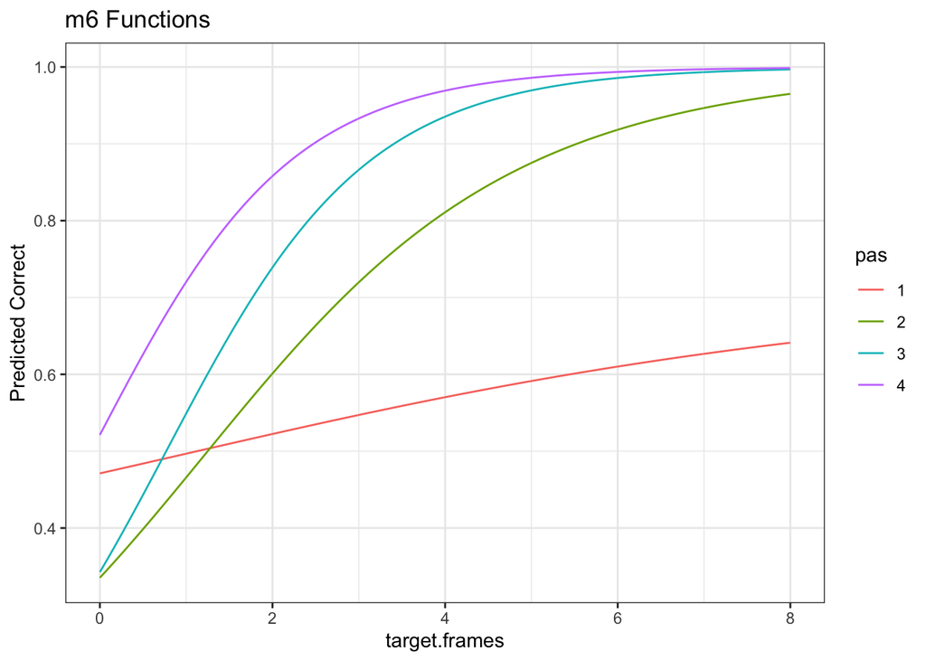

```r
## PLOTTING ##
m6_plot <- ggplot(newdata_with_mean)+
  geom_line(aes(x = target.frames, y = yhat_mean, color = pas))+
  xlim(min = 0, max = 8)+
  labs(title = "m6 Functions", y = "Predicted Correct") +
  theme_bw()

m6_plot
```

**CONTINUATION OF REPORT 5.2i**: m6 includes an interaction between *pas* and *target.frames* as well as their individual effect. The plot illustrates why this interaction is meaningful to include. We can deduce that *target.frames* barely affects correctness if *pas* = 1. Contrarily, for *pas* = 2 and 3 in particular, *target.frames* affects correctness a lot. *pas* = 4 is consistently above all other levels of pas regardless of the *target.frames*, suggesting that being very sure about your answer makes you more likely to answer correctly regardless of the number of target frames. While there is no real data at *target.frames* = 0 nor *target.frames* > 6, the functions were estimated in xlim(0, 8).

$~$

# EXERCISE 6 - Test linear hypotheses

In this section we are going to test different hypotheses. We assume that we have already proved that more objective evidence (longer duration of stimuli) is sufficient to increase accuracy in and of itself and that more subjective evidence (higher PAS ratings) is also sufficient to increase accuracy in and of itself.  
We want to test a hypothesis for each of the three neighbouring differences in PAS, i.e. the difference between 2 and 1, the difference between 3 and 2 and the difference between 4 and 3. More specifically, we want to test the hypothesis that accuracy increases faster with objective evidence if subjective evidence is higher at the same time, i.e. we want to test for an interaction.

### (DB) 1) Fit a model based on the following formula: `correct ~ pas * target.frames + (target.frames | subject))`

```r
m6 <- glmer(correct ~ pas * target.frames + (1 + target.frames|subject), family = binomial(link = logit), data=data)
```

**NB.** The model created in 6.1 was already fitted in exercise 5.3. For the sake of explicitness, it is fitted again in the chunk above.

$~$

#### (MA) i. First, use `summary` (yes, you are allowed to!) to argue that accuracy increases faster with objective evidence for PAS 2 than for PAS 1.

```r
summary(m6)
```

```
## Generalized linear mixed model fit by maximum likelihood (Laplace
##   Approximation) [glmerMod]
##  Family: binomial  ( logit )
## Formula: correct ~ pas * target.frames + (1 + target.frames | subject)
##    Data: data
##
##      AIC      BIC   logLik deviance df.resid
##  19506.1  19595.5  -9742.0  19484.1    25033
##
## Scaled residuals:
##      Min       1Q   Median       3Q      Max
## -19.0111   0.0537   0.1606   0.4849   1.4465
##
## Random effects:
##  Groups  Name          Variance Std.Dev. Corr
##  subject (Intercept)   0.03698  0.1923
##          target.frames 0.02058  0.1434   -0.76
## Number of obs: 25044, groups:  subject, 29
##
## Fixed effects:
##                    Estimate Std. Error z value Pr(>|z|)
## (Intercept)        -0.12163    0.06413  -1.897 0.057872 .
## pas2               -0.57139    0.08940  -6.391 1.65e-10 ***
## pas3               -0.53850    0.13959  -3.858 0.000114 ***
## pas4                0.20157    0.25016   0.806 0.420377
## target.frames       0.11480    0.03708   3.096 0.001960 **
## pas2:target.frames  0.44718    0.03474  12.873  < 2e-16 ***
## pas3:target.frames  0.74869    0.04595  16.293  < 2e-16 ***
## pas4:target.frames  0.75928    0.06840  11.101  < 2e-16 ***
## ---
## Signif. codes:  0 '***' 0.001 '**' 0.01 '*' 0.05 '.' 0.1 ' ' 1
##
## Correlation of Fixed Effects:
##             (Intr) pas2   pas3   pas4   trgt.f ps2:t. ps3:t.
## pas2        -0.461
## pas3        -0.307  0.247
## pas4        -0.174  0.121  0.091
## target.frms -0.811  0.305  0.207  0.123
## ps2:trgt.fr  0.481 -0.874 -0.244 -0.124 -0.428
## ps3:trgt.fr  0.392 -0.278 -0.891 -0.111 -0.358  0.370
## ps4:trgt.fr  0.276 -0.163 -0.121 -0.918 -0.260  0.225  0.200
```

The interaction estimate *target.frames:pas2* is positive (0.45) and significant (p<.001) which means that accuracy increases more steeply with objective evidence (*target.frames*) for *pas2* compared to *pas1*.

On another note, the estimates for *pas2*, *pas3* and *pas4* as shown in the output are not directly interpretable since these are accuracies for *target.frames* = 0, and the lowest possible amount of target frames is 1 in the experiment.

### 2) `summary` won’t allow you to test whether accuracy increases faster with objective evidence for PAS 3 than for PAS 2 (unless you use `relevel`, which you are not allowed to in this exercise). Instead, we’ll be using the function `glht` from the `multcomp` package

#### (MA) i. To redo the test in 6.1.i, you can create a *contrast* vector. This vector will have the length of the number of estimated group-level effects and any specific contrast you can think of can be specified using this. For redoing the test from 6.1.i, the code snippet below will do

```r
## TESTING whether PAS 2 is different from PAS 1 ##
contrast.vector <- matrix(c(0, 0, 0, 0, 0, 1, 0, 0), nrow=1)
gh <- glht(m6, contrast.vector)
print(summary(gh))
```

```
##
##   Simultaneous Tests for General Linear Hypotheses
##
## Fit: glmer(formula = correct ~ pas * target.frames + (1 + target.frames |
##     subject), data = data, family = binomial(link = logit))
##
## Linear Hypotheses:
##        Estimate Std. Error z value Pr(>|z|)
## 1 == 0  0.44718    0.03474   12.87   <2e-16 ***
## ---
## Signif. codes:  0 '***' 0.001 '**' 0.01 '*' 0.05 '.' 0.1 ' ' 1
## (Adjusted p values reported -- single-step method)
```

#### (ADS) ii. Now test the hypothesis that accuracy increases faster with objective evidence for PAS 3 than for PAS 2.

```r
contrast.vector <- matrix(c(0, 0, 0, 0, 0, -1, 1, 0), nrow=1)
gh <- glht(m6, contrast.vector)
print(summary(gh))
```

```
##
##   Simultaneous Tests for General Linear Hypotheses
##
## Fit: glmer(formula = correct ~ pas * target.frames + (1 + target.frames |
##     subject), data = data, family = binomial(link = logit))
##
## Linear Hypotheses:
##        Estimate Std. Error z value Pr(>|z|)
## 1 == 0  0.30151    0.04624   6.521 6.98e-11 ***
## ---
## Signif. codes:  0 '***' 0.001 '**' 0.01 '*' 0.05 '.' 0.1 ' ' 1
## (Adjusted p values reported -- single-step method)
```

#### (MS) iii. Also test the hypothesis that accuracy increases faster with objective evidence for PAS 4 than for PAS 3

```r
contrast.vector <- matrix(c(0, 0, 0, 0, 0, 0, -1, 1), nrow=1)
gh <- glht(m6, contrast.vector)
print(summary(gh))
```

```
##
##   Simultaneous Tests for General Linear Hypotheses
##
## Fit: glmer(formula = correct ~ pas * target.frames + (1 + target.frames |
##     subject), data = data, family = binomial(link = logit))
##
## Linear Hypotheses:
##        Estimate Std. Error z value Pr(>|z|)
## 1 == 0  0.01059    0.07438   0.142    0.887
## (Adjusted p values reported -- single-step method)
```

Accuracy does not increase significantly faster with objective evidence for PAS 4 than for PAS 3 ($\beta=0.01058, z = 0.142, p=0.887$)

#### 3) (DB, MS) Finally, test that whether the difference between PAS 2 and 1 (tested in 6.1.i) is greater than the difference between PAS 4 and 3 (tested in 6.2.iii)

(DB):

```r
## DIFFERENCE between PAS 2 and PAS 1 (repeated from 6.1.i) and difference between PAS 4 and PAS 3 (repeated from 6.2.iii) ##

contrast.matrix <- rbind(c(0, 0, 0, 0, 0, 1, 0, 0), c(0, 0, 0, 0, 0, 0, -1, 1))
rownames(contrast.matrix) <- c("PAS 2-1", "PAS 4-3")
gh <- glht(m6, contrast.matrix)


print(summary(gh))
```

```
##
##   Simultaneous Tests for General Linear Hypotheses
##
## Fit: glmer(formula = correct ~ pas * target.frames + (1 + target.frames |
##     subject), data = data, family = binomial(link = logit))
##
## Linear Hypotheses:
##              Estimate Std. Error z value Pr(>|z|)
## PAS 2-1 == 0  0.44718    0.03474  12.873   <1e-10 ***
## PAS 4-3 == 0  0.01059    0.07438   0.142    0.987
## ---
## Signif. codes:  0 '***' 0.001 '**' 0.01 '*' 0.05 '.' 0.1 ' ' 1
## (Adjusted p values reported -- single-step method)
```

From the table, we see that the estimates are different: PAS2-PAS1 = 0.45 and PAS4-PAS3 = 0.01.

(MS) Next we want to visualize this difference with 95% confidence intervals:

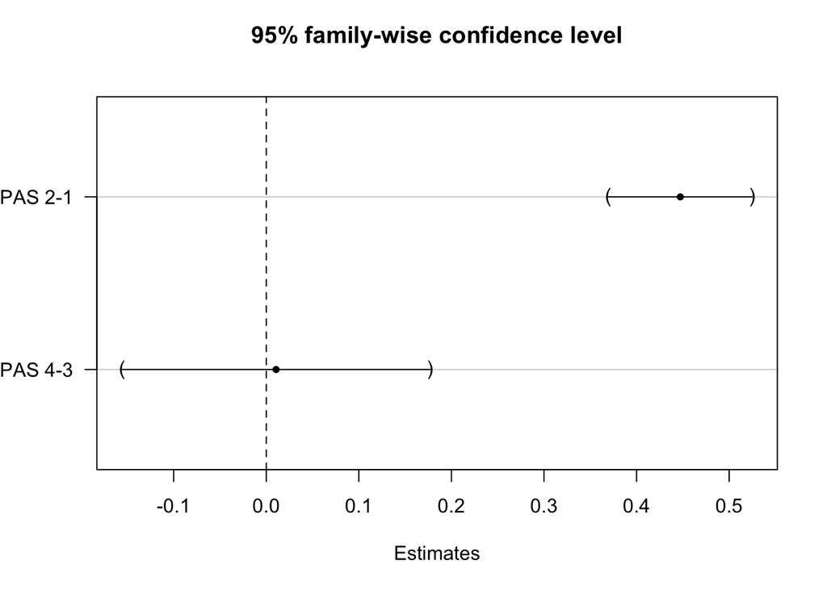

```r
plot(gh, xlab= "Estimates")
```

The 95% confidence intervals for the differences in estimates between PAS2-PAS1 (0.45) and PAS4-PAS3 (0.01) show no overlap (see plot). It is therefore likely that the difference in differences is indeed a true difference.

# EXERCISE 7 - Estimate psychometric functions for the Perceptual Awareness Scale and evaluate them

We saw in 5.3 that the estimated functions went below chance at a target duration of 0 frames (0 ms). This does not seem reasonable, so we will be trying a different approach for fitting here.

We will fit the following function that results in a sigmoid, $f(x) = a + \frac {b - a} {1 + e^{\frac {c-x} {d}}}$

It has four parameters: *a*, which can be interpreted as the minimum accuracy level, *b*, which can be interpreted as the maximum accuracy level, *c*, which can be interpreted as the so-called inflexion point, i.e. where the derivative of the sigmoid reaches its maximum and *d*, which can be interpreted as the steepness at the inflexion point. (When *d* goes towards infinity, the slope goes towards a straight line, and when it goes towards 0, the slope goes towards a step function).

**(MA)**: We can define a function of a residual sum of squares as below

```r
RSS <- function(dataset, par)
{
    ## "dataset" should be a data.frame containing the variables x (target.frames)
    ## and y (correct)
    ## "par" are our four parameters (a numeric vector)
    ## par[1] = a, par[2] = b, par[3] = c, par[4] = d
    x <- dataset$target.frames
    y <- as.numeric(as.character(dataset$correct))
    y.hat <-  par[1] + ((par[2]-par[1])/(1+exp((par[3]-x)/par[4])))## you fill in the estimate of y.hat
    RSS <- sum((y - y.hat)^2)
    return(RSS)
}
```

### (DB) 1) Now, we will fit the sigmoid for the four PAS ratings for Subject 7

```r
subject7 <- data %>%
  filter(subject == 7) %>%
  dplyr::select(target.frames, correct, pas)
```

#### (MS) i. use the function `optim`. It returns a list that among other things contains the four estimated parameters. You should set the following arguments:

```
`par`: you can set _c_ and _d_ as 1. Find good choices for _a_ and _b_ yourself (and argue why they are appropriate)
`fn`: which function to minimise?
`data`: the data frame with _x_ (_target.frames_), and _y_, (_correct_) in it
`method`: 'L-BFGS-B'
`lower`: lower bounds for the four parameters, (the lowest value they can take), you can set _c_ and _d_ as `-Inf`. Find good choices for _a_ and _b_ yourself (and argue why they are appropriate)
`upper`: upper bounds for the four parameters, (the highest value they can take) can set _c_ and _d_ as `Inf`. Find good choices for _a_ and _b_ yourself (and argue why they are appropriate)
```

**(MS):** In the *par* argument, we set a = 0.5 because we believe the minimum accuracy level cannot be lower than chance and b = 1 because it is impossible to have an accuracy score above 100 %. In the *lower* argument, we have set a = 0.5 for the same reason as in the par argument. We also set the *lower* argument for b to be 0.5 because the best accuracy should not be below chance.

In the *upper* argument, we set a = 1 because it would be possible, although unlikely, for even the worst accuracy to be 100 % and b = 1 because the maximum accuracy is 100 %.

$~$

```r
pas1 <- optim(par = c(0.5,1,1,1), fn=RSS, data = filter(subject7, pas == "1"), method = 'L-BFGS-B', lower = c(0.5,0.5,-Inf,-Inf), upper = c(1,1,Inf,Inf))

pas2 <- optim(par = c(0.5,1,1,1), fn=RSS, data = filter(subject7, pas == "2"), method = 'L-BFGS-B', lower = c(0.5,0.5,-Inf,-Inf), upper = c(1,1,Inf,Inf))

pas3 <- optim(par = c(0.5,1,1,1), fn=RSS, data = filter(subject7, pas == "3"), method = 'L-BFGS-B', lower = c(0.5,0.5,-Inf,-Inf), upper = c(1,1,Inf,Inf))

pas4 <- optim(par = c(0.5,1,1,1), fn=RSS, data = filter(subject7, pas == "4"), method = 'L-BFGS-B', lower = c(0.5,0.5,-Inf,-Inf), upper = c(1,1,Inf,Inf))
```

#### (ADS) ii. Plot the fits for the PAS ratings on a single plot (for subject 7) `xlim=c(0, 8)`

Firstly, we need to calculate the predicted values for subject 7 using the estimates we have been given by the optim functions. To create an xlim of 0 to 8, we fabricate x-values using the seq function as done in exercise 5.3ii.

$~$

```r
## FABCRICATING X ##
newdata <- data.frame(cbind("x" = seq(0, 8, by = 0.01)))

## CALCULATING the yhats using the formula a + ((b - a)/(1+exp((c - x)/d))) ##
newdata$yhat1 <- pas1$par[1] + ((pas1$par[2]-pas1$par[1])/(1+exp((pas1$par[3]-newdata$x)/pas1$par[4])))
newdata$yhat2 <- pas2$par[1] + ((pas2$par[2]-pas2$par[1])/(1+exp((pas2$par[3]-newdata$x)/pas2$par[4])))
newdata$yhat3 <- pas3$par[1] + ((pas3$par[2]-pas3$par[1])/(1+exp((pas3$par[3]-newdata$x)/pas3$par[4])))
newdata$yhat4 <- pas4$par[1] + ((pas4$par[2]-pas4$par[1])/(1+exp((pas4$par[3]-newdata$x)/pas4$par[4])))
```

Now we are ready to plot the values:

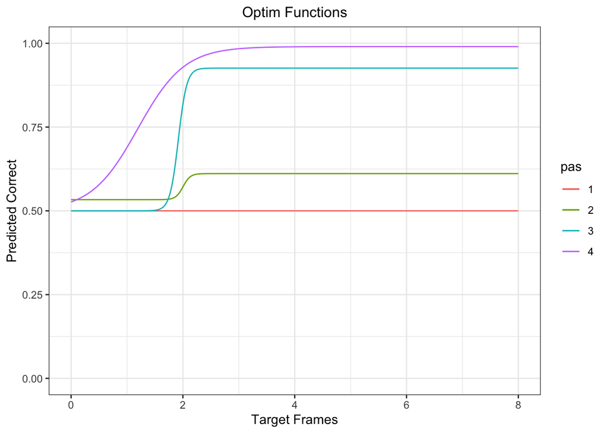

```r
optim_plot <- ggplot(newdata) +
  geom_line(aes(x=x, y=yhat1, color = "1"))+
  geom_line(aes(x=x, y=yhat2, color = "2"))+
  geom_line(aes(x=x, y=yhat3, color = "3"))+
  geom_line(aes(x=x, y=yhat4, color = "4"))+
  scale_color_manual(name = "pas", values = c("1" = "#F8766D", "2" = "#7CAE00", "3" = "#00BFC4", "4" = "#C77CFF"))+
  xlim(c(0,8))+
  ylim(c(0,1))+
  labs(y = "Predicted Correct", x = "Target Frames", title = "Optim Functions")+
  theme_bw()+
  theme(plot.title = element_text(hjust = 0.5, size = 12))

optim_plot
```

#### (MA) iii. Create a similar plot for the PAS ratings on a single plot (for subject 7), but this time based on the model from 6.1 `xlim=c(0, 8)`

We fabricate data once again to create an xlim of (0, 8). In this case, we select subject = 7 in our newdata to later predict y-values for only subject 7:

```r
newdata2 <- data.frame(cbind('target.frames' = rep(seq(0, 8, by = 0.01), 4), "pas" = c(rep(1,801),rep(2,801), rep(3, 801), rep(4, 801)), subject = rep("7")))
```

We fix some classes and use the predict() function to estimate our y-values for subject 7:

```r
newdata2$subject <- as.factor(newdata2$subject)
newdata2$pas <- as.factor(newdata2$pas)
newdata2$target.frames <- as.numeric(newdata2$target.frames)

newdata2$yhat <- predict(m6, newdata = newdata2, type = "response") #response argument defined to keep it on the probablility scale to create sigmoid functions.
```

Now we can plot it:

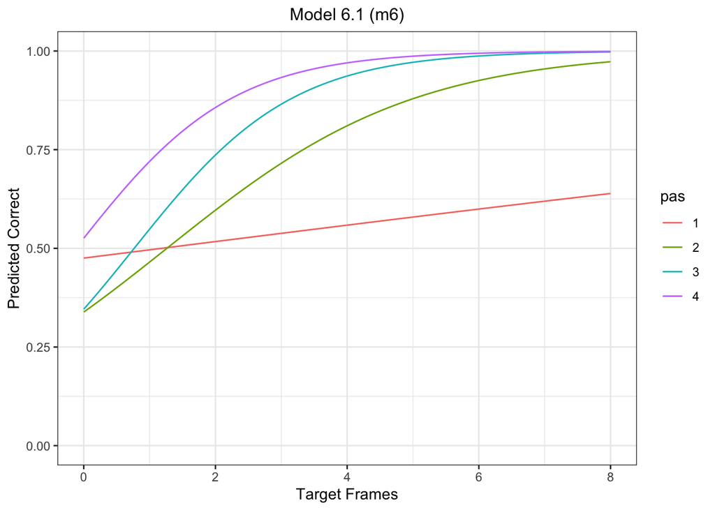

```r
m6_plot <- ggplot(newdata2) +
  geom_line(aes(x=target.frames, y=yhat, color = pas))+
  xlim(c(0,8))+
  ylim(c(0,1))+
  labs(y = "Predicted Correct", x = "Target Frames", title = "Model 6.1 (m6)")+
  theme_bw()+
  theme(plot.title = element_text(hjust = 0.5, size = 12))

m6_plot
```

#### (ADS) iv. Comment on the differences between the fits - mention some advantages and disadvantages of each way

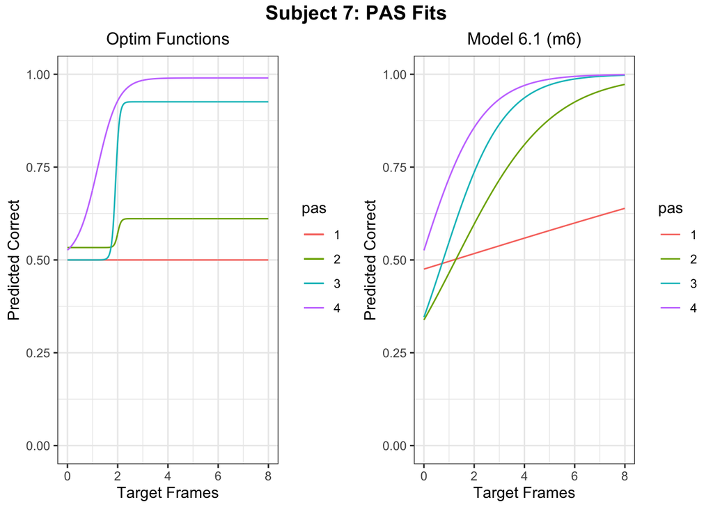

```r
comparison <- ggarrange(optim_plot, m6_plot)

annotate_figure(comparison, top = text_grob("Subject 7: PAS Fits", color = "black", face = "bold", size = 14))
```

Firstly, the optim function has solved the issue of having accuracy below 50 % at *target.frames* = 0 as we have defined the accepted minimum accuracy to be a = 0.5. With the model from 6.1 (m6), this is not the case as all PAS functions except *pas4* goes below an accuracy of 0.5 at *target.frames* = 0.

Generally, the tendencies for the functions are similar on both plots. However, the optim functions behave more as step-functions where objective evidence (*target.frames*) only improves accuracy (*predicted correct*) up to a certain point to which it then stagnates. On the other hand, model 6.1 has a more smooth curve where accuracy continuously improves as the objective evidence (*target.frames*) increases.

Another thing to note is that the optim function for *pas2* behaves quite differently. This may be due to the estimates being fitted only on data from subject 7 whereas the estimates from the model from 6.1 (m6) has been fitted on the entire dataset. Thus, while both functions have estimated y-values from subject7, model 6.1 has more information to base its estimates on.

$~$

### (ADS, DB) 2) Finally, estimate the parameters for all subjects and each of their four PAS ratings. Then plot the estimated function at the group-level by taking the mean for each of the four parameters, *a*, *b*, *c* and *d* across subjects. A function should be estimated for each PAS-rating (it should look somewhat similar to Fig. 3 from the article: https://doi.org/10.1016/j.concog.2019.03.007)

(ADS) To estimate the parameters for all subjects a for-loop was created to repeat the procedure done in exercise 7.1:

```r
final_df <- data.frame(matrix(ncol = 0, nrow = 0))

for (subject_number in 1:24) {
  #filter for subject
  data_subset <- data %>%
  filter(subject == subject_number) %>%
  dplyr::select(target.frames, correct, pas)

  #find a, b, c, d for the 4 PAS
  pas1 <- optim(par = c(0.5,1,1,1), fn=RSS, data = filter(data_subset, pas == "1"), method = 'L-BFGS-B', lower = c(0.5,0.5,-Inf,-Inf), upper = c(1,1,Inf,Inf))

  pas2 <- optim(par = c(0.5,1,1,1), fn=RSS, data = filter(data_subset, pas == "2"), method = 'L-BFGS-B', lower = c(0.5,0.5,-Inf,-Inf), upper = c(1,1,Inf,Inf))

  pas3 <- optim(par = c(0.5,1,1,1), fn=RSS, data = filter(data_subset, pas == "3"), method = 'L-BFGS-B', lower = c(0.5,0.5,-Inf,-Inf), upper = c(1,1,Inf,Inf))

  pas4 <- optim(par = c(0.5,1,1,1), fn=RSS, data = filter(data_subset, pas == "4"), method = 'L-BFGS-B', lower = c(0.5,0.5,-Inf,-Inf), upper = c(1,1,Inf,Inf))

  #adding parameters to final dataframe
  temp_df <- rbind(pas1$par, pas2$par, pas3$par, pas4$par)
  colnames(temp_df) <- c("a", "b", "c", "d")
  temp_df <- as.data.frame(temp_df)
  temp_df$pas <- rep(1:4)
  temp_df$subject <- rep(subject_number, 4)

final_df <- rbind(final_df, temp_df)

}
```

(DB) Then we find mean estimates of the four parameters:

```r
mean_estimates <- final_df %>%
  group_by(pas) %>%
  summarize("a_mean" = mean(a),
            "b_mean" = mean(b),
            "c_mean" = mean(c),
            "d_mean" = mean(d))
```

(DB) We calculate the estimated y-values by using the formula $\hat y = a + \frac {b - a} {1 + e^{\frac {c-x} {d}}}$

```r
## FABRICATING X ##
newdata7.2 <- data.frame(cbind("x" = seq(0, 8, by = 0.01)))

## CALCULATING the yhats using the formula a + ((b - a)/(1+exp((c - x)/d))) ##
newdata7.2$yhat1 <- mean_estimates$a_mean[1] + ((mean_estimates$b_mean[1]-mean_estimates$a_mean[1])/(1+exp((mean_estimates$c_mean[1]-newdata7.2$x)/mean_estimates$d_mean[1])))

newdata7.2$yhat2 <- mean_estimates$a_mean[2] + ((mean_estimates$b_mean[2]-mean_estimates$a_mean[2])/(1+exp((mean_estimates$c_mean[2]-newdata7.2$x)/mean_estimates$d_mean[2])))

newdata7.2$yhat3 <- mean_estimates$a_mean[3] + ((mean_estimates$b_mean[3]-mean_estimates$a_mean[3])/(1+exp((mean_estimates$c_mean[3]-newdata7.2$x)/mean_estimates$d_mean[3])))

newdata7.2$yhat4 <- mean_estimates$a_mean[4] + ((mean_estimates$b_mean[4]-mean_estimates$a_mean[4])/(1+exp((mean_estimates$c_mean[4]-newdata7.2$x)/mean_estimates$d_mean[4])))
```

(DB) Plotting group level functions:

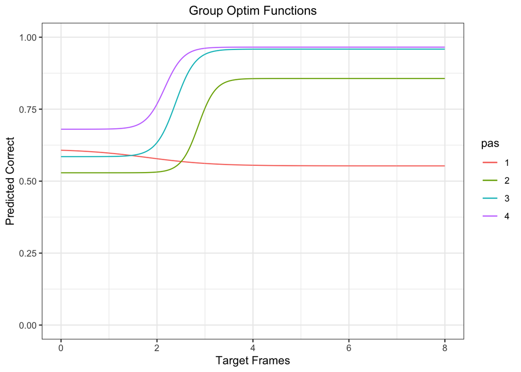

```r
group_optim_plot <- ggplot(newdata7.2) +
  geom_line(aes(x=x, y=yhat1, color = "1"))+
  geom_line(aes(x=x, y=yhat2, color = "2"))+
  geom_line(aes(x=x, y=yhat3, color = "3"))+
  geom_line(aes(x=x, y=yhat4, color = "4"))+
  scale_color_manual(name = "pas", values = c("1" = "#F8766D", "2" = "#7CAE00", "3" = "#00BFC4", "4" = "#C77CFF"))+
  xlim(c(0,8))+
  ylim(c(0,1))+
  labs(y = "Predicted Correct", x = "Target Frames", title = "Group Optim Functions")+
  theme_bw()+
  theme(plot.title = element_text(hjust = 0.5, size = 12))

group_optim_plot
```

#### (MS) i. compare with the figure you made in 5.3.ii and comment on the differences between the fits - mention some advantages and disadvantages of both.

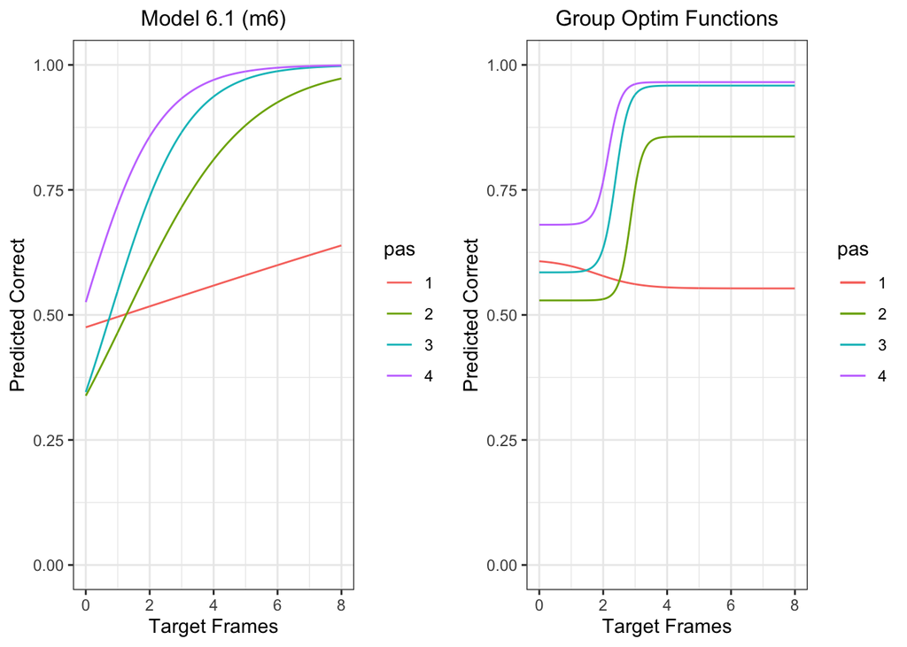

```r
ggpubr::ggarrange(m6_plot, group_optim_plot)
```

The **Group Optim functions plot** makes more sense compared to the model from 5.3ii (**m6**) as it has predicted correctness greater than chance at all times. However, the *pas1*-function in the optim plot behaves weirdly as it declines from target frames 1 to 3 which could be considered a disadvantage. Contrarily, predicted correctness increases for the m6 *pas1*-function which makes sense.